# Combining the best of two worlds: Python & R

May 27, 2020

## Outline

- Motivation for combining R and Python
- Levels of integration
  - Break into homogeneous chunks
  - Use a “bridge”
  - Truly integrated workflow

## Why Python or R for data science?

- Both
  - open-source programming language with a large community
  - new libraries or tools are added continuously
  - interface to compiled language libraries

[figure not shown]

- - general purpose programming language
  - clean, efficient, modular design (software deployment)
  - scipy, scikit-learn, Keras, PyTorch
- - statistical modeling and data analysis language
  - great for visualization
  - Bioconductor (edgeR, DESeq2), tidyverse, ggplot2, shiny

## Many “Python versus R” comparisons out there…

> Which [#superheroe](https://twitter.com/hashtag/superheroe?src=hash&ref_src=twsrc%5Etfw) are you?([#batman](https://twitter.com/hashtag/batman?src=hash&ref_src=twsrc%5Etfw) Vs. [#Superman](https://twitter.com/hashtag/Superman?src=hash&ref_src=twsrc%5Etfw)) == ([#R](https://twitter.com/hashtag/R?src=hash&ref_src=twsrc%5Etfw) Vs. [#Python](https://twitter.com/hashtag/Python?src=hash&ref_src=twsrc%5Etfw))? [#datascience](https://twitter.com/hashtag/datascience?src=hash&ref_src=twsrc%5Etfw) [@roopamu](https://twitter.com/roopamu?ref_src=twsrc%5Etfw) https://t.co/B1gO8MT1Zr [pic.twitter.com/GR3pUiZ6rS](https://t.co/GR3pUiZ6rS)

> — Antoine (@AntoineTrdc) [November 1, 2015](https://twitter.com/AntoineTrdc/status/660953806168072193?ref_src=twsrc%5Etfw)

## Why combining the two?

- any data scienctist constantly combines tools from various sources
- unlikely that all functionality is available from a single source
- nice to have fewer scripts / steps / intermediate files
- use case (why I started looking into combining R and Python):
  - primarly use R/BioC for analysis of single cell data
  - want to make use of scvelo python package for RNA-velocity analysis

## Levels of integration

1. Break into homogeneous chunks
   - each chunk is pure R or pure python
   - chunks are run separately from each other
   - input and output is read from and stored in intermediate files
2. Use a “bridge”
   - primarily work with one language
   - use a **specialized package** that allows calling the 2nd language from the first
3. Truly integrated workflow
   - use a single script or notebook
   - run it through a **pair of connected R and python processes**
   - **objects are shared** between these processes (no need for input/output files)

## Approach 1: break into pure R/python chunks

- can be organized using workflow tools
  - (make, Snakemake, knime, custom pipelines, …)
- Advantages
  - flexible, can combine any tool (scripts, binaries, …)
- Disadvantages
  - no real integration
  - need to store state in intermediate files
  - need for cut-and-glue code

## Approach 2: Use a “bridge”

- made possible by “bridge” packages
  - Call python from R: [reticulate](https://rstudio.github.io/reticulate/)
  - Call R from python: [rpy2](https://rpy2.github.io/)
- Advantages
  - easy to use (primarly use one language)
- Disadvantages
  - indirect access to “other” language
  - need to learn bridge package syntax

## Display conventions (also for exercises)

I will use background colors to indicate code from different languages:

```r
# R code
R.version.string
```

```
## [1] "R version 4.0.0 (2020-04-24)"
```

```python
# python code
import sys
sys.version
```

```
## '3.6.8 (default, Aug  7 2019, 17:28:10) \n[GCC 4.8.5 20150623 (Red Hat 4.8.5-39)]'
```

```bash
# shell script (bash)
echo ${BASH_VERSION}
```

```
## 4.2.46(2)-release
```

## Example: Calling python from R using [reticulate](https://rstudio.github.io/reticulate/)

```r
library(reticulate)
os <- import("os")
os$listdir(".")
```

```
## [1] "styles.css"                      "introduction.Rmd"                "introduction.html"               "figures"
## [5] "ideas.txt"                       "rstudio_reticulate_examples.Rmd" "echo"
```

```python
import os
os.listdir(".")
```

```
## ['styles.css', 'introduction.Rmd', 'introduction.html', 'figures', 'ideas.txt', 'rstudio_reticulate_examples.Rmd', 'echo']
```

## [reticulate](https://rstudio.github.io/reticulate/) type conversions

| R | Python | Examples |
| --- | --- | --- |
| Single-element vector | Scalar | 1, 1L, TRUE, “foo” |
| Multi-element vector | List | c(1.0, 2.0, 3.0), c(1L, 2L, 3L) |
| List of multiple types | Tuple | list(1L, TRUE, “foo”) |
| Named list | Dict | list(a = 1L, b = 2.0), dict(x = x_data) |
| Matrix/Array | NumPy ndarray | matrix(c(1,2,3,4), nrow = 2, ncol = 2) |
| Data Frame | Pandas DataFrame | data.frame(x = c(1,2,3), y = c(“a”, “b”, “c”)) |
| Function | Python function | function(x) x + 1 |
| Raw | Python bytearray | as.raw(c(1:10)) |
| NULL, TRUE, FALSE | None, True, False | NULL, TRUE, FALSE |

## Example: Calling R from python using [rpy2](https://rpy2.github.io/)

```python
import rpy2.robjects as robjects
pi = robjects.r['pi']
pi[0]
```

```
## 3.141592653589793
```

```r
pi
```

```
## [1] 3.141593
```

## [rpy2](https://rpy2.github.io/) type conversions

- rpy2’s object conversion system is complex and powerful:
  - a lower-level interface (implemented as protocols): rpy2.rinterface
  - a higher-level interface using converter functions: rpy2.robjects.conversion.Converter()
  - custom converters can be implemented for new objects
- for details see: https://rpy2.github.io/doc/latest/html/robjects_convert.html

## Approach 3: Integrated workflow

- use a single script or notebook
  - use a pair of connected R and python processes
  - processes can share objects similarly as with “bridge” approach
  - supported by RStudio: rmarkdown + reticulate, see also [blog post](https://blog.rstudio.com/2018/03/26/reticulate-r-interface-to-python/)
  - supported by Jupyter: rpy2.ipython.rmagic
- Advantages
  - easy to use
  - can mostly use native code
- Disadvantages
  - increased complexity of environment (ok once it is setup)
  - need to learn some specific syntax (limited)

## “I don’t like notebooks”

- presentation by Joel Grus at JupyterCon 2018:
  - [link to slides (Google docs)](https://docs.google.com/presentation/d/1n2RlMdmv1p25Xy5thJUhkKGvjtV-dkAIsUXP-AL4ffI/edit#slide=id.g362da58057_0_1)
  - presentation refer to Jupyter notebooks, but applies equally to RStudio notebooks
- in a nutshell:
  - possible to run chunks out of order and to have an inconsistent state (shown output is not what you would get upon rerun)
  - the hidden state makes it difficult to understand what’s going on
  - better: use markdown (compiled in order, no bad surprises)

## Example: RStudio markdown

Code cells are declared in a header:

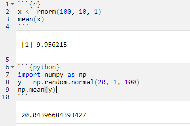

The special objects r and py can be used to access the “other side”:

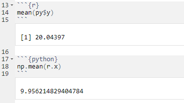

## Example: Jupyter notebook

Code cells are declared to contain R by starting with %R (single line) or %%R (multiple lines) ([details](https://rpy.sourceforge.io/rpy2/doc-dev/html/interactive.html?highlight=rmagic#module-rpy2.ipython.rmagic)):

```
%R [-i INPUT] [-o OUTPUT] [...] [code [code ...]]
```

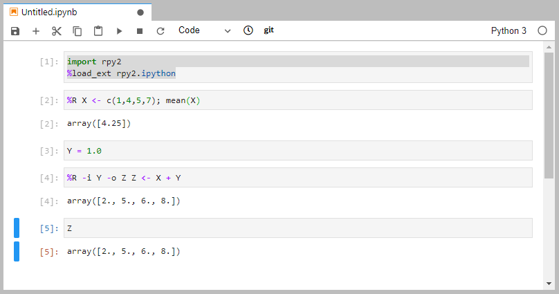

Thank you!